# Class 7: Aspects of Social Movement Activity

Social movements and the media

[Dr. Michael C. Zeller](https://michaelzeller.de)

# Opening notes

[Open Sticker](https://tenor.com/view/open-gif-14209777)from [Open Stickers](https://tenor.com/search/open-stickers)

## Presentation groups

Presentations line-up

| Date | Presenters | Method |
| --- | --- | --- |

# Opening questions

- Where do you get your news?
- When you read the news (thinking only of ‘traditional media’ for the moment), what is reported, generally?

[So Many Questions Dr Roger Bentley GIF](https://tenor.com/view/so-many-questions-dr-roger-bentley-the-mole-people-curious-dont-understand-gif-18789236)from [So Many Questions GIFs](https://tenor.com/search/so+many+questions-gifs)

## Media: the translator of social movements

What are the mechanisms of…

- movements advancing their **frames** (*Class 3*),
- **mobilisation**, **recruitment**, **participation** (*Class 4*),
- **tactics** and **strategies** achieving results (*Class 6*)?

often it is the media (including social media)

how media covers a movement is often how most people know about it

- **big practical and theoretical stakes**
- often plays a gatekeeper role

## Past and present eras: a change of arena

[figure not shown]

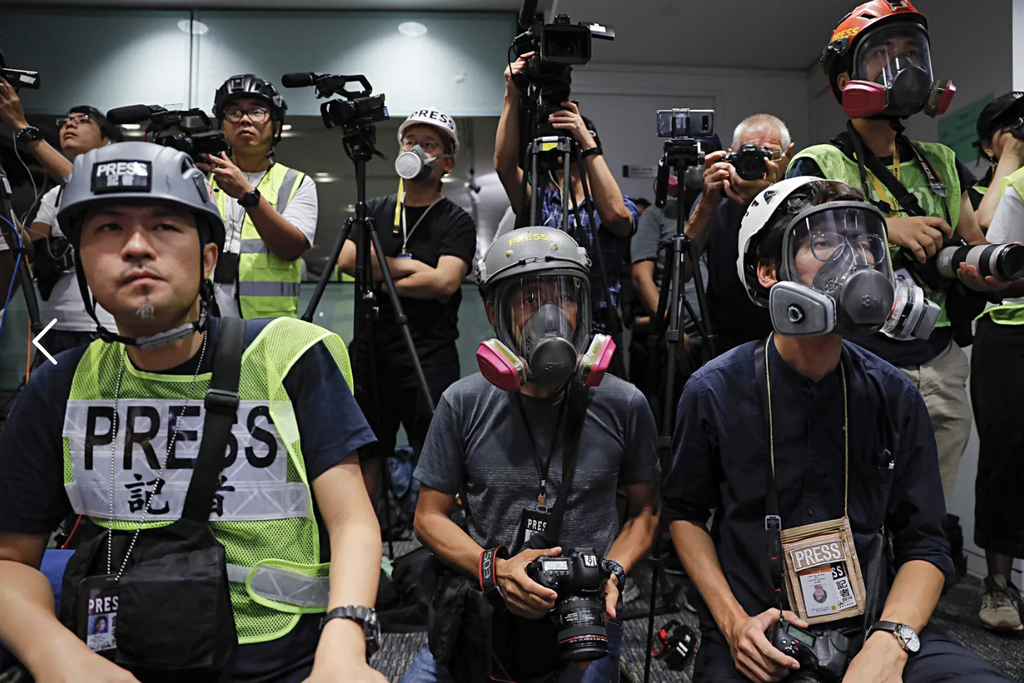

## Past and present eras: a change of arena

[figure not shown]

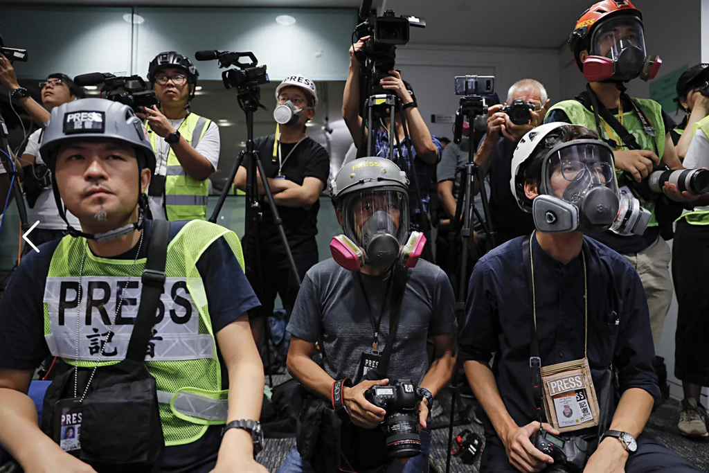

- previous eras: direct action, confrontation between movements and authorities more common
  - here: barricade in Paris, 1848
- modern era: indirect contention filtered through media more common
  - here: press pack ahead of movement press conference in Hong Kong
  - ‘the whole world is watching’ era
    - the prospect (for movements) and peril (for targets/authorities) now? the whole world may be watching

# Poll: movements and media

[figure not shown]

Take the survey at **https://forms.gle/ngepuqqzaFu8nCfBA**

- ever personally supported a movement online?
- how do media generally portray *protesters*?
- what helpd a movement get media coverage?
- should movements tailor their messaging/framing to gain more attention?
- does social media encourage ‘slacktivism’?
- traditional media coverage still necessary for movements in an age of social media?

Questions about movements: (1) type of media most important for movement’s visibility? (2) movement strategically plans actions to generate media coverage? (3) media coverage of movement generally favourable? (4) audience the movement mainly tries to influence? (5) movement often succeeds in getting its narratives into the media? (6) has the movement influenced public debate?

[interactive chart not shown]

how do media generally portray *protesters*?

[interactive chart not shown]

most likely to help a movement get media coverage?

[interactive chart not shown]

## Poll results - boosting media coverage

should movements tailor their messaging/framing to gain more attention?

[interactive chart not shown]

is traditional media coverage still necessary for movement success in an age of social media?

[interactive chart not shown]

## Poll results - online

ever personally supported a movement online?

[interactive chart not shown]

does social media encourage ‘slacktivism’?

[interactive chart not shown]

# Open data - POLDEM issues

- Visualisation
- Explanatory note
- Data table

[interactive chart not shown]

| month | Cultural conservatism | Cultural liberalism | Economy (private) | Economy (public) | Environment | Other | Political/institutional | Regionalism | Xenophobia |
| --- | --- | --- | --- | --- | --- | --- | --- | --- | --- |
| 2000-01-01 | 1 | 33 | 31 | 78 | 17 | 24 | 38 | 46 | 21 |
| 2000-02-01 | 1 | 99 | 29 | 34 | 7 | 47 | 81 | 30 | 9 |
| 2000-03-01 | 5 | 44 | 21 | 33 | 15 | 19 | 31 | 24 | 1 |
| 2000-04-01 | 2 | 18 | 14 | 22 | 8 | 12 | 18 | 18 | 12 |
| 2000-05-01 | 6 | 17 | 21 | 28 | 4 | 27 | 23 | 22 | 8 |
| 2000-06-01 | 2 | 14 | 23 | 39 | 10 | 34 | 25 | 15 | 7 |
| 2000-07-01 | 2 | 25 | 20 | 22 | 18 | 8 | 28 | 88 | 15 |
| 2000-08-01 | 0 | 17 | 20 | 21 | 11 | 16 | 13 | 70 | 38 |
| 2000-09-01 | 0 | 30 | 88 | 331 | 63 | 16 | 20 | 29 | 8 |
| 2000-10-01 | 1 | 34 | 25 | 85 | 57 | 12 | 26 | 46 | 17 |

[output cut: 182 more lines]

**Data download**

# Movements and (traditional) media coverage

- (some) factors influencing media coverage
- Jennings and Saunders (2019)
  - research questions, importance
  - data and methods
  - hypotheses
  - results

[Kaa Snake GIF](https://tenor.com/view/kaa-snake-jungle-book-mowgli-hypnosis-gif-21167178)from [Kaa GIFs](https://tenor.com/search/kaa-gifs)

## Movements and (traditional) media coverage

*Factors that may affect media coverage*

- day of the week (McCarthy, Mcphail, and Smith 1996)
- other news events (set number of ‘column inches’)
- weather (Madestam et al. 2013)
- celebrities (Atkinson and DeWitt 2018)
- size of event, violence/disruptiveness, whether there is a counterdemonstration (Denardo 1985; McCarthy, Mcphail, and Smith 1996; Biggs 2018)

## Movements and (traditional) media coverage

*Factors that may affect media coverage*

- size of event, violence/disruptiveness, whether there is a counterdemonstration (Denardo 1985; McCarthy, Mcphail, and Smith 1996; Biggs 2018)
  - larger protests get reported – duh!
  - **media attention cycles** (*topicality*) (McCarthy et al. 1996)
    - if Germany’s energy is in the news, then energy/climate protests may get more attention
  - **counterdemonstrations** may help attract more attention (media bias for ‘*both sides*’)

## Jennings and Saunders (2019) - RQs

- Why do some protests get reported on and others not?
- What protests get covered over the long term and why?
- Why? What’s at stake?
  - **demonstrations** are **effective** when they not only hit newspaper headlines, but create a “**sustained shift in media focus, onto the issues that the demonstration raises**” (p. 2287)

## Jennings and Saunders (2019) - data and methods

- **48 street demonstrations** in **nine countries** between **2009 - 2013**
  - surveys – how do you think this is done?
  - Belgium, Czechia, Denmark, Germany, Netherlands, Spain, Sweden, Switzerland, and United Kingdom
  - any important contextual considerations?

> The design of our study is **large-N** (based on a sample of demonstrations, avoiding the tautology endemic to many studies of media attention to protest, which **select cases based on their being reported in the media**), at the same time as putting protest in context. (pp. 2293-4)

## Jennings and Saunders (2019) - data and methods

- **48 street demonstrations** in **nine countries** between **2009 - 2013**
  - surveys – how do you think this is done?
  - Belgium, Czechia, Denmark, Germany, Netherlands, Spain, Sweden, Switzerland, and United Kingdom
- **DV**: level of national media attention to related issue *over time*
- **IVs**:
  - number of participants
  - presence of counterdemo
  - extent of violence
  - presence of trigger event
  - **any ‘omitted variables’ problems**

## Jennings and Saunders (2019) - hypotheses

| Feature | Static | Dynamic |
| --- | --- | --- |
| Number of participants | larger = more coverage | short- and long-term coverage |
| Contentiousness | high = more coverage | short- and long-term coverage |
| Exhibit violence | violence = more coverage | short-term coverage, long-term losses/costs |
| Trigger event | trigger = more coverage | short-term coverage |

do these expectations make sense to you? do you disagree with any?

## Jennings and Saunders (2019) - reg table

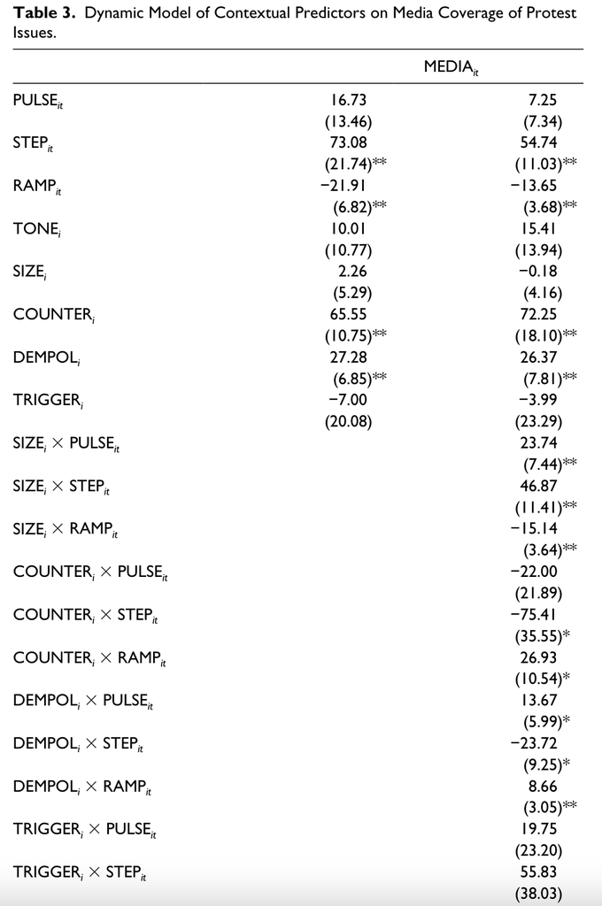

## Reading a regression table

Remember: regression is a tool for understanding a phenomenon as a linear function (generally) → (y = mx + b)

1. Numbers not in parentheses next to a variable: **regression coefficient**: expected change in DV for a one-unit increase in IV. NB: ositive or negative relationship?
2. Numbers inside parentheses next to a variable: **standard error**: estimate of the standard deviation of the coefficient
3. Asterisks/‘stars’: **statistical significance**: probability of results as extreme as observed result, under the assumption that the null hypothesis is correct. Smaller p-value means such an observation would be less likely under null hypothesis; hence, significance. Statistical significance suggests more precise estimates—NOT necessarily that one IV is more important than another.

## Jennings and Saunders (2019) - reg table

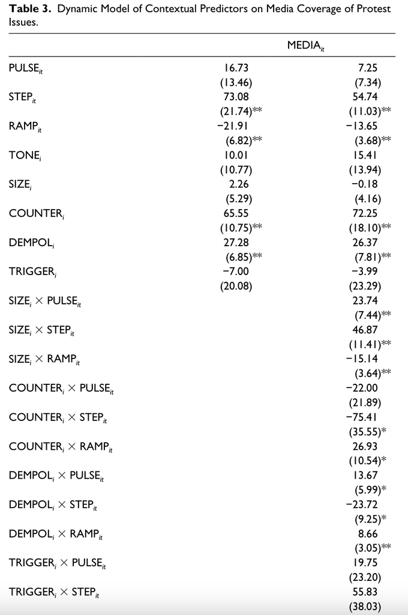

- Numbers not in parentheses next to a variable: regression coefficient: expected change in DV for a one-unit increase in IV.
- Numbers inside parentheses next to a variable: standard error: estimate of the standard deviation of the coefficient
- Asterisks/‘stars’: statistical significance: probability of results as extreme as observed result, under the assumption that the null hypothesis is correct. Smaller p-value means such an observation would be less likely under null hypothesis; hence, significance. Statistical significance suggests more precise estimates.

## Jennings and Saunders (2019) - marginal effects

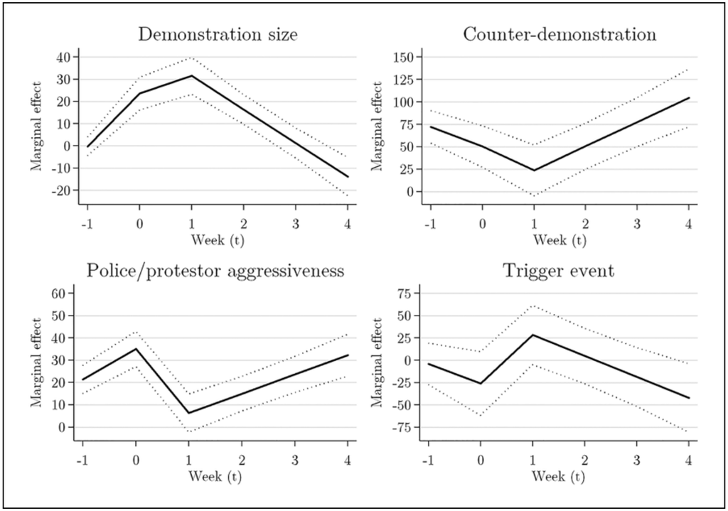

## Movement responses - type of media

type of media most important for the movement?

[interactive chart not shown]

## Movement responses - coverage

movement plans actions to generate media coverage?

[interactive chart not shown]

media coverage of movement generally favourable?

[interactive chart not shown]

## Movement responses - audience

which audience is the movement trying to influence?

[interactive chart not shown]

## Movement responses - media success

movement succeeds in getting its narratives in the media?

[interactive chart not shown]

movement has been successful at influencing public debate?

[interactive chart not shown]

# Social movements and social media

- from #hashtag to mobilisation
  - BLM example
- Slacktivism

[Social Icons Sticker](https://tenor.com/view/social-icons-gif-26956119)from [Social Icons Stickers](https://tenor.com/search/social+icons-stickers)

## From #hashtag to mobilisation

(USA Today on BLM)

[video not shown]

## From #hashtag to mobilisation

(USA Today on BLM)

social media breaks down traditional media gatekeeper roles

- helped BLM form coalition of K-Pop fans, Anonymous, celebrities, etc.
- enhanced BLM’s ‘narrative capacity’ (i.e., efficacy in advancing frames, shifting status quo)
  - cf. ‘disruptive capacity’ and ‘institutional/political capacity’

## Movements and social media - revisiting a debate

*Class 4*: we listened to Tufecki and social media mobilisation and ‘old-school organisation’ - *can attract more participants, but perhaps with less commitment*

- “Slacktivism” & network structure of protest media coverage

[video not shown]

# Movements, media, and astroturfing

- Torches of Freedom
- astroturfing
- knock-on effects

[Turf War Turf GIF](https://tenor.com/view/turf-war-turf-war-gif-26783173)from [Turf War GIFs](https://tenor.com/search/turf+war-gifs)

## Torches of Freedom

1929, Easter Sunday Parade: a Tabubruch? more emancipation for women?

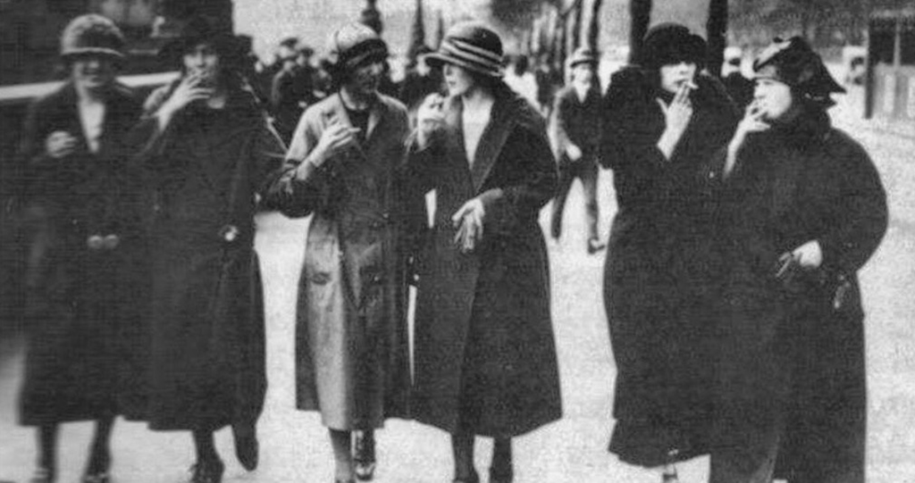

## Movements, media, and astroturfing

**astroturfing** - manipulation of public sphere (media, information, movement scene)

- fake ‘grassroots movements’ are a common form of astroturfing
  - a way of harnessing the ‘power of movement’
  - e.g., ‘Tea Party movement’ - a ‘*people’s*’ movement funded by Koch Industries
- **any examples, instances of this in/around your case?**

## Torches of Freedom

- Edward Bernays (‘father of PR’)
- working for American Tobacco Company from 1927
  - ‘smoke instead of eating’/thinness advertising
  - medical experts enlisted to promote smoking over eating sweets
- Easter Day Parade, 1929
  - Bernays paid feminist movement members to smoke on the parade
  - ‘*while [the women] should be good looking, they should not look too model-y*’
- 1923: women accounted for 5 per cent of cigarette sales; 1929: 12 per cent; 1935: 18 per cent

[figure not shown]

[figure not shown]

## Astroturfing: knock-on effects

- when movements are sometimes faked/manufactured, it undermines potential credibility of other movements
  - are people being ‘paid to protest’? who is ‘behind’ this protest?
  - questioning motives/genuineness of movements
    - **Letzte Generation**: funding from Climate Emergency Fund (U.S.), including Aileen Getty, heir of Getty Oil company
    - **Just Stop Oil** (U.K.): large amounts of funding from Climate Emergency Fund, from Dale Vince (green energy industrialist)
  - examples of conspiracy beliefs in U.S. (George Soros, Sandy Hook, etc.)

see further, on the theory: Herman, E. S., & Chomsky, N. (1988). *Manufacturing consent: The political economy of the mass media*. Random House.

# Any questions, concerns, feedback for this class?

Anonymous feedback here: https://forms.gle/AjHt6fcnwZxkSg4X8

Alternatively, please send me an email: m.zeller@lmu.de

Questions about movements next meeting: (1) Is coalition with other movements important for this movement’s success? (2) movement participated in broad “umbrella coalitions”? (3) Are coalition partners seen as temporary allies rather than long-term partners? (4) Do coalition actions tend to be more effective for the movement? (5) Are the movement’s coalitions are primarily local rather than national or international? (6) Does the movement have supportive allies in one or more political party?

## References

Atkinson, Matthew D., and Darin DeWitt. 2018. “Does Celebrity Issue Advocacy Mobilize Issue Publics?” *Political Studies*, no. 2. https://doi.org/10.1177/0032321717751294.

Biggs, Michael. 2018. “Size Matters: Quantifying Protest by Counting Participants.” *Sociological Methods and Research* 47 (3): 351–83. https://doi.org/10.1177/0049124116629166.

Denardo, James. 1985. *Power in Numbers: The Political Strategy of Protest and Rebellion*. Princeton: Princeton University Press.

Jennings, Will, and Clare Saunders. 2019. “Street Demonstrations and the Media Agenda: An Analysis of the Dynamics of Protest Agenda Setting.” *Comparative Political Studies* 52 (13-14): 2283–313. https://doi.org/10.1177/0010414019830736.

Madestam, Andreas, Daniel Shoag, Stan Veuger, and David Yanagizawa-Drott. 2013. “Do Political Protests Matter? Evidence from the Tea Party Movement.” *The Quarterly Journal of Economics* 128 (4): 1633–85. https://doi.org/10.1093/qje/qjt021.Advance.

McCarthy, John D, Clark Mcphail, and Jackie Smith. 1996. “Images of Protest: Dimensions of Selection Bias in Media Coverage of Washington Demonstrations, 1982 and 1991.” *American Sociological Review* 61 (3): 478–99.